# About this file

The dataset includes quantitative and qualitative data from various educational institutions that have implemented virtual reality in their teaching methodologies. It contains information on student demographics, VR usage statistics, and feedback from both students and educators. This comprehensive dataset is invaluable for researchers, educators, and policymakers looking to understand the efficacy of VR in educational settings. 📊🎓

https://www.kaggle.com/datasets/waqi786/impact-of-virtual-reality-on-education

# 關於此檔案

這些數據包含來自不同教育機構的定量和定性數據，這些機構已在教學方法中引入虛擬實境 (VR)。數據包括學生的人口統計資訊、VR 使用統計以及來自學生和教育者的反饋。這份全面的數據集對於研究人員、教育者和政策制定者而言，都是理解 VR 在教育環境中效果的寶貴資源。📊🎓

### Members: 張祐豪、洪慈徽、彭榆蓁、李昕諦

```python
import pandas as pd

# Load the uploaded CSV file
# 加載上傳的 CSV 檔案
file_path = './Virtual_Reality_in_Education_Impact.csv'
data = pd.read_csv(file_path)

# Display those rows to understand the structure of the dataset
# 顯示這些行以了解數據集的結構
data
```

|  | Student_ID | Age | Gender | Grade_Level | Field_of_Study | Usage_of_VR_in_Education | Hours_of_VR_Usage_Per_Week | Engagement_Level | Improvement_in_Learning_Outcomes | Subject | Instructor_VR_Proficiency | Perceived_Effectiveness_of_VR | Access_to_VR_Equipment | Impact_on_Creativity | Stress_Level_with_VR_Usage | Collaboration_with_Peers_via_VR | Feedback_from_Educators_on_VR | Interest_in_Continuing_VR_Based_Learning | Region | School_Support_for_VR_in_Curriculum |
| --- | --- | --- | --- | --- | --- | --- | --- | --- | --- | --- | --- | --- | --- | --- | --- | --- | --- | --- | --- | --- |
| 0 | STUD0001 | 13 | Non-binary | Postgraduate | Science | No | 6 | 1 | Yes | Computer Science | Intermediate | 3 | Yes | 5 | High | No | Neutral | No | South America | No |
| 1 | STUD0002 | 16 | Non-binary | Undergraduate | Medicine | No | 6 | 1 | Yes | Math | Beginner | 2 | Yes | 3 | Low | Yes | Positive | No | Oceania | No |
| 2 | STUD0003 | 15 | Prefer not to say | High School | Science | No | 4 | 5 | Yes | Art | Advanced | 5 | Yes | 2 | Low | Yes | Neutral | Yes | Oceania | No |
| 3 | STUD0004 | 24 | Female | Postgraduate | Engineering | Yes | 2 | 4 | No | Economics | Beginner | 5 | No | 3 | High | No | Neutral | No | Europe | Yes |
| 4 | STUD0005 | 22 | Non-binary | Undergraduate | Arts | Yes | 10 | 3 | No | Art | Beginner | 4 | Yes | 1 | Medium | No | Negative | Yes | North America | Yes |
| ... | ... | ... | ... | ... | ... | ... | ... | ... | ... | ... | ... | ... | ... | ... | ... | ... | ... | ... | ... | ... |
| 4995 | STUD4996 | 18 | Male | Undergraduate | Engineering | No | 10 | 4 | No | Biology | Advanced | 1 | Yes | 1 | High | Yes | Neutral | Yes | Asia | No |
| 4996 | STUD4997 | 25 | Male | High School | Medicine | No | 5 | 1 | Yes | Art | Advanced | 4 | Yes | 5 | Medium | No | Negative | Yes | South America | No |
| 4997 | STUD4998 | 25 | Female | High School | Engineering | No | 1 | 4 | No | Computer Science | Beginner | 2 | No | 3 | Low | Yes | Negative | Yes | North America | No |
| 4998 | STUD4999 | 22 | Female | Undergraduate | Science | No | 4 | 3 | Yes | Math | Beginner | 3 | Yes | 3 | Low | No | Negative | Yes | Africa | No |
| 4999 | STUD5000 | 21 | Male | Undergraduate | Medicine | Yes | 1 | 1 | No | Economics | Intermediate | 2 | Yes | 4 | Low | No | Positive | Yes | Asia | Yes |

5000 rows × 20 columns

# 數據欄位及編碼對應關係 (Column Details and Processing Results)

## 1. `Student_ID`

- **原始資料 (Original Data)**: 學生 ID，例如 `STUD0001`, `STUD0002`
- **處理後 (Processed)**: 編碼為數字（從 `0` 開始的整數標籤）
- **範例 (Example)**: `STUD0001 → 0`, `STUD0002 → 1`

## 2. `Age`

- **原始資料 (Original Data)**: 年齡（數值，Age as numerical value）
- **處理後 (Processed)**: 保持不變 (No changes)
- **範例 (Example)**: `13 → 13`

## 3. `Gender`

- **原始資料 (Original Data)**: 性別 (Gender)，例如 `Male`, `Female`, `Non-binary`, `Prefer not to say`
- **處理後 (Processed)**: 編碼為數字 (Encoded to numerical values)
  - `Female → 0`
  - `Male → 1`
  - `Non-binary → 2`
  - `Prefer not to say → 3`

## 4. `Grade_Level`

- **原始資料 (Original Data)**: 年級 (Grade Level)，例如 `High School`, `Undergraduate`, `Postgraduate`
- **處理後 (Processed)**: 編碼為數字 (Encoded to numerical values)
  - `High School → 0`
  - `Undergraduate → 2`
  - `Postgraduate → 1`

## 5. `Field_of_Study`

- **原始資料 (Original Data)**: 學科領域 (Field of Study)，例如 `Science`, `Medicine`, `Engineering`, `Arts`
- **處理後 (Processed)**: 編碼為數字 (Encoded to numerical values)
  - `Arts → 0`
  - `Business → 1`
  - `Education → 2`
  - `Engineering → 3`
  - `Law → 4`
  - `Medicine → 5`
  - `Science → 6`

## 6. `Usage_of_VR_in_Education`

- **原始資料 (Original Data)**: 是否使用 VR (VR Usage)，例如 `Yes`, `No`
- **處理後 (Processed)**: 編碼為數字 (Encoded to numerical values)
  - `No → 0`
  - `Yes → 1`

## 7. `Hours_of_VR_Usage_Per_Week`

- **原始資料 (Original Data)**: 每週使用 VR 時數 (Weekly VR usage hours, numerical value)
- **處理後 (Processed)**: 保持不變 (No changes)
- **範例 (Example)**: `6 → 6`

## 8. `Engagement_Level`

- **原始資料 (Original Data)**: 參與程度 (Engagement Level, numerical value)
- **處理後 (Processed)**: 保持不變 (No changes)
- **範例 (Example)**: `1 → 1`

## 9. `Improvement_in_Learning_Outcomes`

- **原始資料 (Original Data)**: 學習成果改善 (Improvement in Learning Outcomes)，例如 `Yes`, `No`
- **處理後 (Processed)**: 編碼為數字 (Encoded to numerical values)
  - `Yes → 1`
  - `No → 0`

## 10. `Subject`

- **原始資料 (Original Data)**: 科目 (Subject)，例如 `Math`, `Art`, `Economics`, `Computer Science`
- **處理後 (Processed)**: 編碼為數字 (Encoded to numerical values)
  - `Math → 5`
  - `Art → 0`
  - `Economics → 3`
  - `Computer Science → 2`

## 11. `Instructor_VR_Proficiency`

- **原始資料 (Original Data)**: VR 熟練度 (Instructor VR Proficiency)，例如 `Beginner`, `Intermediate`, `Advanced`
- **處理後 (Processed)**: 編碼為數字 (Encoded to numerical values)
  - `Beginner → 1`
  - `Intermediate → 2`
  - `Advanced → 0`

## 12. `Perceived_Effectiveness_of_VR`

- **原始資料 (Original Data)**: 對 VR 的感知效果 (Perceived Effectiveness of VR, numerical value)
- **處理後 (Processed)**: 保持不變 (No changes)
- **範例 (Example)**: `3 → 3`

## 13. `Access_to_VR_Equipment`

- **原始資料 (Original Data)**: 是否有 VR 設備 (Access to VR Equipment)，例如 `Yes`, `No`
- **處理後 (Processed)**: 編碼為數字 (Encoded to numerical values)
  - `Yes → 1`
  - `No → 0`

## 14. `Impact_on_Creativity`

- **原始資料 (Original Data)**: 創造力影響程度 (Impact on Creativity, numerical value)
- **處理後 (Processed)**: 保持不變 (No changes)
- **範例 (Example)**: `5 → 5`

## 15. `Stress_Level_with_VR_Usage`

- **原始資料 (Original Data)**: VR 使用壓力 (Stress Level with VR Usage)，例如 `High`, `Medium`, `Low`
- **處理後 (Processed)**: 編碼為數字 (Encoded to numerical values)
  - `High → 0`
  - `Medium → 2`
  - `Low → 1`

## 16. `Collaboration_with_Peers_via_VR`

- **原始資料 (Original Data)**: 是否與同儕合作 (Collaboration with Peers via VR)，例如 `Yes`, `No`
- **處理後 (Processed)**: 編碼為數字 (Encoded to numerical values)
  - `Yes → 1`
  - `No → 0`

## 17. `Feedback_from_Educators_on_VR`

- **原始資料 (Original Data)**: 教師對 VR 的回饋 (Feedback from Educators on VR)，例如 `Positive`, `Neutral`, `Negative`
- **處理後 (Processed)**: 編碼為數字 (Encoded to numerical values)
  - `Positive → 2`
  - `Neutral → 1`
  - `Negative → 0`

## 18. `Interest_in_Continuing_VR_Based_Learning`

- **原始資料 (Original Data)**: 是否有繼續學習的興趣 (Interest in Continuing VR-Based Learning)，例如 `Yes`, `No`
- **處理後 (Processed)**: 編碼為數字 (Encoded to numerical values)
  - `Yes → 1`
  - `No → 0`

## 19. `Region`

- **原始資料 (Original Data)**: 地區 (Region)，例如 `North America`, `Europe`, `Oceania`, `South America`
- **處理後 (Processed)**: 編碼為數字 (Encoded to numerical values)
  - `Africa → 0`
  - `Asia → 1`
  - `Europe → 2`
  - `North America → 3`
  - `Oceania → 4`
  - `South America → 5`

## 20. `School_Support_for_VR_in_Curriculum`

- **原始資料 (Original Data)**: 是否有學校支持 (School Support for VR in Curriculum)，例如 `Yes`, `No`
- **處理後 (Processed)**: 編碼為數字 (Encoded to numerical values)
  - `Yes → 1`
  - `No → 0`

```python
from sklearn.preprocessing import LabelEncoder

# Identify categorical columns
# 確認類別型欄位
categorical_columns = data.select_dtypes(include=['object']).columns

# Create a copy to store the encoded data
# 建立副本以儲存編碼後的數據
encoded_data = data.copy()

# Apply Label Encoding to each categorical column
# 對每個類別型欄位進行標籤編碼
label_encoders = {}
for column in categorical_columns:
    encoder = LabelEncoder()
    encoded_data[column] = encoder.fit_transform(data[column])
    label_encoders[column] = encoder  # Store the encoder for future reference
                                      # 儲存編碼器以供日後參考


# Save the encoded dataset to a new CSV file
# 將編碼後的數據集保存為新的 CSV 檔案
# Dear mates, please use the file Encoded_Virtual_Reality_Data.csv to fetch the data.
# 各位同學要拉資料請使用 Encoded_Virtual_Reality_Data.csv 這個檔案
encoded_data.to_csv("Encoded_Virtual_Reality_Data.csv", index=False)
print("Encoded data saved to 'Encoded_Virtual_Reality_Data.csv'.")

# Display those rows of the encoded dataset
# 顯示編碼後數據集
encoded_data
```

```
Encoded data saved to 'Encoded_Virtual_Reality_Data.csv'.
```

|  | Student_ID | Age | Gender | Grade_Level | Field_of_Study | Usage_of_VR_in_Education | Hours_of_VR_Usage_Per_Week | Engagement_Level | Improvement_in_Learning_Outcomes | Subject | Instructor_VR_Proficiency | Perceived_Effectiveness_of_VR | Access_to_VR_Equipment | Impact_on_Creativity | Stress_Level_with_VR_Usage | Collaboration_with_Peers_via_VR | Feedback_from_Educators_on_VR | Interest_in_Continuing_VR_Based_Learning | Region | School_Support_for_VR_in_Curriculum |
| --- | --- | --- | --- | --- | --- | --- | --- | --- | --- | --- | --- | --- | --- | --- | --- | --- | --- | --- | --- | --- |
| 0 | 0 | 13 | 2 | 1 | 6 | 0 | 6 | 1 | 1 | 2 | 2 | 3 | 1 | 5 | 0 | 0 | 1 | 0 | 5 | 0 |
| 1 | 1 | 16 | 2 | 2 | 5 | 0 | 6 | 1 | 1 | 5 | 1 | 2 | 1 | 3 | 1 | 1 | 2 | 0 | 4 | 0 |
| 2 | 2 | 15 | 3 | 0 | 6 | 0 | 4 | 5 | 1 | 0 | 0 | 5 | 1 | 2 | 1 | 1 | 1 | 1 | 4 | 0 |
| 3 | 3 | 24 | 0 | 1 | 3 | 1 | 2 | 4 | 0 | 3 | 1 | 5 | 0 | 3 | 0 | 0 | 1 | 0 | 2 | 1 |
| 4 | 4 | 22 | 2 | 2 | 0 | 1 | 10 | 3 | 0 | 0 | 1 | 4 | 1 | 1 | 2 | 0 | 0 | 1 | 3 | 1 |
| ... | ... | ... | ... | ... | ... | ... | ... | ... | ... | ... | ... | ... | ... | ... | ... | ... | ... | ... | ... | ... |
| 4995 | 4995 | 18 | 1 | 2 | 3 | 0 | 10 | 4 | 0 | 1 | 0 | 1 | 1 | 1 | 0 | 1 | 1 | 1 | 1 | 0 |
| 4996 | 4996 | 25 | 1 | 0 | 5 | 0 | 5 | 1 | 1 | 0 | 0 | 4 | 1 | 5 | 2 | 0 | 0 | 1 | 5 | 0 |
| 4997 | 4997 | 25 | 0 | 0 | 3 | 0 | 1 | 4 | 0 | 2 | 1 | 2 | 0 | 3 | 1 | 1 | 0 | 1 | 3 | 0 |
| 4998 | 4998 | 22 | 0 | 2 | 6 | 0 | 4 | 3 | 1 | 5 | 1 | 3 | 1 | 3 | 1 | 0 | 0 | 1 | 0 | 0 |
| 4999 | 4999 | 21 | 1 | 2 | 5 | 1 | 1 | 1 | 0 | 3 | 2 | 2 | 1 | 4 | 1 | 0 | 2 | 1 | 1 | 1 |

5000 rows × 20 columns

```python
# Validate whether there are any flaws in the data processing. Team members, please "ignore" this piece of code!
# 驗證資料處理上面是否有瑕疵，請各位組員自行「忽視」這一份code!
# Load the provided files
# 加載提供的檔案
encoded_file_path = './Encoded_Virtual_Reality_Data.csv'
original_file_path = './Virtual_Reality_in_Education_Impact.csv'

# Read both files
# 讀取兩個檔案
encoded_data = pd.read_csv(encoded_file_path)
original_data = pd.read_csv(original_file_path)

# Validate the column mapping and structure
# 驗證欄位的映射和結構
mapping_issues = {}
for column in original_data.select_dtypes(include=['object']).columns:
    # Retrieve original values and corresponding encoded values
    # 提取原始值及其對應的編碼值
    if column in encoded_data.columns:
        original_values = original_data[column].dropna().unique()
        encoded_values = encoded_data[column].dropna().unique()

        # Check LabelEncoder mappings
        # 檢查 LabelEncoder 的映射
        try:
            encoder = LabelEncoder()
            encoder.fit(original_data[column].dropna())
            encoded_mapping = dict(zip(original_values, encoder.transform(original_values)))

            # Compare generated encoded values with the provided encoded file
            # 將生成的編碼值與提供的編碼檔案進行比較
            actual_encoded_values = encoded_data[column].dropna().map({v: k for k, v in encoded_mapping.items()})
            if not all(actual_encoded_values.isin(original_values)):
                mapping_issues[column] = "Mismatch in mapping or unexpected values."
        except Exception as e:
            mapping_issues[column] = f"Error during mapping validation: {e}"
    else:
        mapping_issues[column] = "Column missing in encoded data."


if not mapping_issues:
    mapping_issues = "no Error沒有任何問題"
mapping_issues
```

```
'no Error沒有任何問題'
```

## 統計分析、資料視覺化 Statistical analysis and data visualization

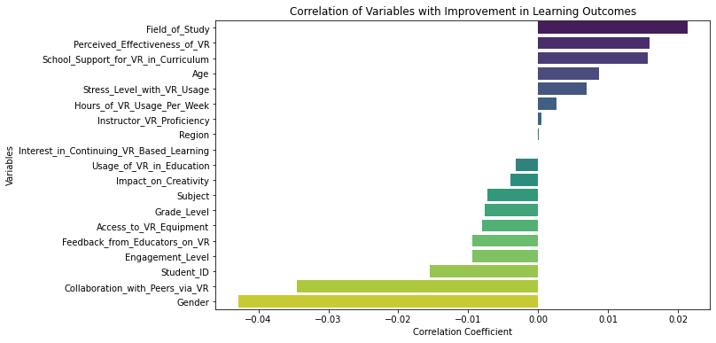

```
Field_of_Study                              0.021356
Perceived_Effectiveness_of_VR               0.015967
School_Support_for_VR_in_Curriculum         0.015722
Age                                         0.008739
Stress_Level_with_VR_Usage                  0.006967
Hours_of_VR_Usage_Per_Week                  0.002572
Instructor_VR_Proficiency                   0.000450
Region                                      0.000124
Interest_in_Continuing_VR_Based_Learning   -0.000065
Usage_of_VR_in_Education                   -0.003254
Name: Improvement_in_Learning_Outcomes, dtype: float64
```

```python
import pandas as pd
import seaborn as sns
import matplotlib.pyplot as plt

# Calculate correlations with "Improvement_in_Learning_Outcomes"
# 計算與 「Improvement_in_Learning_Outcomes」 的相關性
correlations = encoded_data.corr()["Improvement_in_Learning_Outcomes"].sort_values(ascending=False)

# Exclude self-correlation (correlation of a variable with itself)
# 排除自相關（變數與自身的相關性）
correlations = correlations[correlations.index != "Improvement_in_Learning_Outcomes"]

# Visualize the correlations
# 視覺化相關性
plt.figure(figsize=(10, 6))
sns.barplot(x=correlations.values, y=correlations.index, palette="viridis")
plt.title("Correlation of Variables with Improvement in Learning Outcomes")
plt.xlabel("Correlation Coefficient")
plt.ylabel("Variables")
plt.show()

# Display the top correlated variables
# 顯示最相關的變數
correlations.head(10)
```

#### First variable screening. By understanding which variables have the highest correlation with the target variable, further in-depth analyses focus on these variables.

#### 首先變數篩選。透過了解哪些變數與目標變數的相關性最高，進一步聚焦於這些變數進行深入分析。

### Highest correlated variable

#### 1. Field_of_Study (subject area, correlation: 0.021356)

- The impact of subject area on the improvement of learning outcomes is positive but the correlation is very weak, which may indicate that subject area has limited impact on the improvement of learning outcomes.

#### 3. School_Support_for_VR_in_Curriculum (School support for VR in curriculum, correlation: 0.015722)

- The level of school support for VR may slightly affect the learning outcomes, but the correlation is still weak.

#### 最高相關的變數

1. Field_of_Study (學科領域, 相關性：0.021356)
   - 學科領域對學習成果改善的影響雖然是正向的，但相關性非常弱，這可能表示學科領域對學習成果的改善影響有限。
2. Perceived_Effectiveness_of_VR (VR感知效果, 相關性：0.015967)
   - 學生對 VR 有效性的感知與學習成果的改善有一定的正相關，但影響幅度不大。
3. School_Support_for_VR_in_Curriculum (學校對VR課程的支援, 相關性：0.015722)
   - 學校對 VR 支援的程度可能略微影響學習成果，但相關性仍然很弱。

### 1. Academic Level and Field of Study 年級與研究領域

- Explore how grade level or field of study influences VR adoption and effectiveness:
  - Does VR usage vary significantly between high school, undergraduate, and postgraduate students?
  - Are certain fields of study (e.g., Engineering vs. Arts) more likely to benefit from VR technology?
- 探索年級或研究領域如何影響 VR 的採用和成效
  - VR 的使用在高中生、本科生和研究生之間是否有顯著差異？
  - 某些研究領域 (例如工程 vs. 藝術) 是否有不同的學習成果？

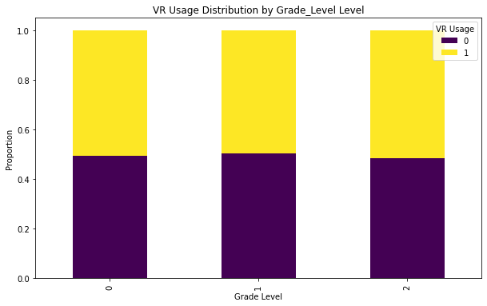

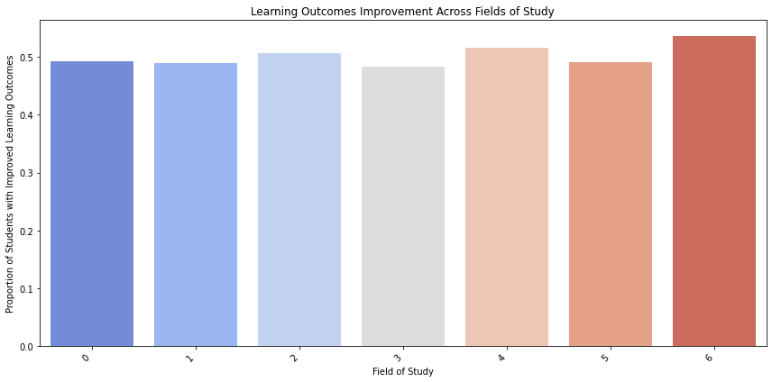

```python
# 堆疊條形圖: 不同年級的 VR 使用比例
# Stacked Bar Chart: Percentage of VR use by grade level
academic_level_vr = encoded_data.groupby("Grade_Level")["Usage_of_VR_in_Education"].value_counts(normalize=True).unstack()
academic_level_vr.plot(kind="bar", stacked=True, figsize=(10, 6), colormap="viridis")
plt.title("VR Usage Distribution by Grade_Level Level")
plt.xlabel("Grade Level")
plt.ylabel("Proportion")
plt.legend(title="VR Usage")
plt.show()

# 長條圖: 不同研究領域的學習成果改善
# Bar chart: Improved learning outcomes in different fields of study
field_of_study_outcomes = encoded_data.groupby('Field_of_Study')['Improvement_in_Learning_Outcomes'].mean().reset_index()
plt.figure(figsize=(12, 6))
sns.barplot(data=field_of_study_outcomes, x='Field_of_Study', y='Improvement_in_Learning_Outcomes', palette='coolwarm')
plt.title('Learning Outcomes Improvement Across Fields of Study')
plt.xlabel('Field of Study')
plt.ylabel('Proportion of Students with Improved Learning Outcomes')
plt.xticks(rotation=45, ha='right')
plt.tight_layout()
plt.show()
```

#### Grade level:

- `High School → 0`
- `Undergraduate → 2`
- `Postgraduate → 1`

#### : Field of Study

- `Arts → 0`
- `Business → 1`
- `Education → 2`
- `Engineering → 3`
- `Law → 4`
- `Medicine → 5`
- `Science → 6`

### 2. Learning Outcomes and Engagement 學習成果與參與

- Investigate the relationship between VR usage and learning outcomes:
  - Does the number of hours spent using VR correlate with improvement in learning outcomes?
  - How does engagement level relate to perceived effectiveness of VR?
- 調查 VR 使用與學習成果之間的關係：
  - 使用 VR 的時數是否與學習成果的改善相關？
  - 參與度與學習成果有何關聯？

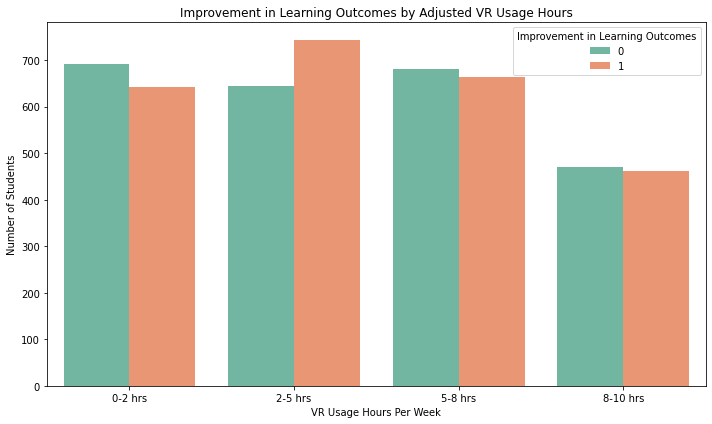

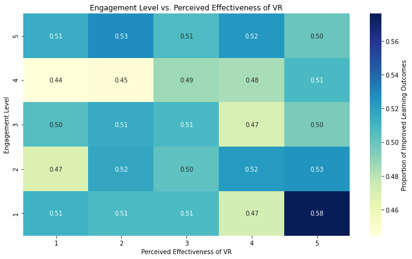

```python
# 堆疊長條圖: 使用 VR 的時數與學習成果的相關
# 將使用 VR 的時數分為區間
# Stacked Bar Charts: Correlation of Hours of VR Use with Learning Outcomes
# Split the number of hours of VR use into zones
encoded_data['VR_Usage_Category'] = pd.cut(
    encoded_data['Hours_of_VR_Usage_Per_Week'],
    bins=[0, 2, 5, 8, 10],
    labels=['0-2 hrs', '2-5 hrs', '5-8 hrs', '8-10 hrs'],
    include_lowest=True
)

# 計算每個 VR 使用時數區間中，學習成果的分佈
# Calculate the distribution of learning outcomes for each VR usage hour interval
usage_outcome_counts = encoded_data.groupby(['VR_Usage_Category', 'Improvement_in_Learning_Outcomes']).size().reset_index(name='Count')

# 繪製堆疊長條圖
# Plot the stacked bar chart
plt.figure(figsize=(10, 6))
bar_plot= sns.barplot(
    data=usage_outcome_counts,
    x='VR_Usage_Category',
    y='Count',
    hue='Improvement_in_Learning_Outcomes',
    palette='Set2'
)

handles, labels = bar_plot.get_legend_handles_labels()
plt.legend(
    handles=handles,
    labels=labels,
    title='Improvement in Learning Outcomes',
    loc='upper right'
)
plt.title('Improvement in Learning Outcomes by Adjusted VR Usage Hours')
plt.xlabel('VR Usage Hours Per Week')
plt.ylabel('Number of Students')
plt.tight_layout()
plt.show()

# 熱力圖: 參與度與 VR 感知效果的關係
# Heatmap: Engagement versus VR Perceptual Effectiveness
engagement_outcome_pivot = encoded_data.pivot_table(
    values='Improvement_in_Learning_Outcomes',
    index='Engagement_Level',
    columns='Perceived_Effectiveness_of_VR',
    aggfunc='mean'
)
engagement_outcome_pivot = engagement_outcome_pivot.iloc[::-1]
plt.figure(figsize=(10, 6))
sns.heatmap(engagement_outcome_pivot, annot=True, fmt=".2f", cmap='YlGnBu', cbar_kws={'label': 'Proportion of Improved Learning Outcomes'})
plt.title('Engagement Level vs. Perceived Effectiveness of VR')
plt.xlabel('Perceived Effectiveness of VR')
plt.ylabel('Engagement Level')
plt.tight_layout()
plt.show()
```

#### 分析結果:

- **使用 VR 的時數**:分析顯示每週使用 2-5 小時的學生中學習成果改善最為顯著。
- **參與度影響**：參與度的高低並不會影響到VR的感知效果 但比較特別是低參與度及高VR的感知效果有較高的相關性(0.58)，可能是因為資料中有離群的數據或是有特別的因素而有較高的結果。

#### Analysis results:

- **Hours of VR use**: Analyses showed the most significant improvements in learning outcomes among students who used VR 2-5 hours per week.
- **Engagement effect**: The level of participation did not affect the perceived effect of VR However, there was a higher correlation (0.58) comparing the perceived effect of low participation and high VR in particular, which may be due to outlier data in the data or a special factor for the higher results.

### 3. Regional and Institutional Support 地區與學校支援

- Explore how geographical regions and school support influence VR usage:
  - Are students in certain regions more likely to have access to VR equipment?
  - How does school support for VR in the curriculum impact students’ interest in continuing VR-based learning?
- 探索地理區域和學校支援如何影響 VR 的使用：
  - 某些地區的學生是否更有可能使用 VR 設備？
  - 學校在課程中對 VR 的支援如何影響學生學習成果？

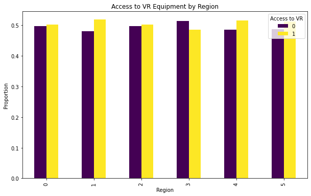

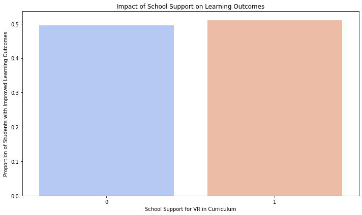

```python
# 分組條形圖: 不同地區的 VR 設備可用性
# Grouping Bar Chart: VR Equipment Availability by Region
region_vr = encoded_data.groupby("Region")["Access_to_VR_Equipment"].value_counts(normalize=True).unstack()
region_vr.plot(kind="bar", figsize=(10, 6), colormap="viridis")
plt.title("Access to VR Equipment by Region")
plt.xlabel("Region")
plt.ylabel("Proportion")
plt.legend(title="Access to VR")
plt.show()

# 長條圖:學校支援與學習成果的關係
# Bar chart: The relationship between school support and learning outcomes
school_support_outcomes = encoded_data.groupby('School_Support_for_VR_in_Curriculum')['Improvement_in_Learning_Outcomes'].mean().reset_index()
plt.figure(figsize=(10, 6))
sns.barplot(data=school_support_outcomes, x='School_Support_for_VR_in_Curriculum', y='Improvement_in_Learning_Outcomes', palette='coolwarm')
plt.title('Impact of School Support on Learning Outcomes')
plt.xlabel('School Support for VR in Curriculum')
plt.ylabel('Proportion of Students with Improved Learning Outcomes')
plt.tight_layout()
plt.show()
```

#### Region:

- `Africa → 0`
- `Asia → 1`
- `Europe → 2`
- `North America → 3`
- `Oceania → 4`
- `South America → 5`

#### 分析結果:

- **地區資源分布**：VR 設備的可用性在不同地區之間分布相對平均，經濟或地區資源差異對學生接觸 VR 的機會影響不大。
- **學校支援**：支援 VR 課程的學校中，學生的學習成果與支援VR的學校比例影響不大。

#### Analysis results:

- **Regional Resource Distribution**: The availability of VR equipment is relatively evenly distributed among different regions, and the differences in economic or regional resources do not have a significant impact on students' access to VR.
- **School support**: The impact of student learning outcomes in schools supporting VR programmes on the proportion of schools supporting VR was not significant.

### 結論

- **VR 使用影響因子**：年級與地區資源對 VR 使用的影響不顯著，顯示使用機會相對均勻。
- **學習成果因素**：教育、法律、科學領域以及每週使用 2-5 小時的學生學習成果改善最為顯著。
- **參與度與 VR 感知**：參與度與 VR 感知效果整體關聯性不大，但低參與度與高感知效果的特殊相關性可能受離群值或其他因素影響。
- **學校支援影響**：支援 VR 課程的比例對學生學習成果影響有限。

### Conclusion

- **VR Use Impact Factor**: Grade level and regional resources do not have a significant impact on VR use, indicating relatively even access.
- **Factors for Learning Outcomes**: Improvements in learning outcomes were most pronounced in education, law, and science fields, and among students who used VR 2-5 hours per week.
- **Engagement and VR Perception**: There was little overall correlation between engagement and VR perceptual effects, but the particular correlation between low engagement and high perceptual effects may be influenced by outliers or other factors.
- **School Support Impact**: The proportion of VR programmes supported had limited impact on student learning outcomes.

## 監督式學習 Supervised Learning

### Predicting Improvement in Learning Outcomes

Store the features and target as variables X and y respectively.  
將特徵及目標以X, y作為變數分別進行儲存

```python
X = encoded_data.drop(columns='Improvement_in_Learning_Outcomes')
y = encoded_data['Improvement_in_Learning_Outcomes']
```

Split the data into a 7:3 ratio, with 70% for the training set and 30% for the test set.  
將資料區分成7: 3 訓練集佔0.7 測試集佔0.3

```python
from sklearn.model_selection import train_test_split
X_train, X_test, y_train, y_test = train_test_split(X, y, test_size=0.3, random_state=128)
```

To avoid large variations or outliers in the data, standardization is applied to modify the data values.  
為了避免資料差異過大或是過於離群，因此透過標準化來修改數據內容

```python
from sklearn.preprocessing import StandardScaler

sc = StandardScaler()
sc.fit(X_train)
X_train_std = sc.transform(X_train)
X_test_std = sc.transform(X_test)
```

```python
from sklearn.ensemble import RandomForestClassifier
import numpy as np

# 使用隨機森林篩選特徵
rf = RandomForestClassifier(random_state=42)
rf.fit(X_train_std, y_train)

# 獲取特徵重要性
importances = rf.feature_importances_
indices = np.argsort(importances)[::-1]  # 按重要性排序
print("特徵重要性:", importances)
print("特徵排序:", indices)

# 選擇前五個重要特徵
X_train_selected = X_train_std[:, indices[:5]]
X_test_selected = X_test_std[:, indices[:5]]
```

```
特徵重要性: [0.14307261 0.09947122 0.04761409 0.03840942 0.06811317 0.02317101
 0.08491073 0.05431526 0.06882605 0.03809875 0.05589215 0.02260379
 0.05574209 0.03674262 0.02090695 0.03468699 0.02259374 0.06257726
 0.0222521 ]
特徵排序: [ 0  1  6  8  4 17 10 12  7  2  3  9 13 15  5 11 16 18 14]
```

1. Using KNN  
   To enable the model to automatically find the optimal parameter combination, param_grid is used to define the search space, and GridSearchCV is applied to tune the parameters and evaluate the performance of the KNN model. This process identifies the best parameters that maximize the model's accuracy.

為了讓模型能夠自動尋找最佳的參數組合，因此利用 param_grid 定義搜索空間並透過 GridSearchCV 對 KNN 模型進行參數調整和性能評估以選出能最大化模型準確率的最佳參數。 (1) n_neighbors（鄰居數量） 含義：K 表示在 KNN 模型中，判斷一個樣本的分類時，考慮最近的 K 個鄰居。 (2) weights（權重參數） 含義：決定鄰居對預測結果的貢獻方式。 (3) metric（距離度量） 含義：計算樣本之間距離的方法。

```python
from sklearn.model_selection import GridSearchCV

# 定義 K 值範圍
param_grid = {
    'n_neighbors': range(1, 50),  # K 值從 1 到 50
    'weights': ['uniform', 'distance'],  # 測試權重參數
    'metric': ['euclidean', 'manhattan']  # 測試不同的距離度量
}
```

```python
from sklearn.neighbors import KNeighborsClassifier
# 創建 KNN 模型
knn = KNeighborsClassifier()
```

```python
# 使用 GridSearchCV
grid_search = GridSearchCV(knn, param_grid, cv=5, scoring='accuracy', n_jobs=-1)
grid_search.fit(X_train_selected, y_train)
```

```
GridSearchCV(cv=5, estimator=KNeighborsClassifier(), n_jobs=-1,
             param_grid={'metric': ['euclidean', 'manhattan'],
                         'n_neighbors': range(1, 50),
                         'weights': ['uniform', 'distance']},
             scoring='accuracy')
```

```python
# 獲取最佳參數
print("最佳參數:", grid_search.best_params_)
print("最佳準確率:", grid_search.best_score_)

# 使用最佳模型測試
best_knn = grid_search.best_estimator_
accuracy = best_knn.score(X_test_selected, y_test)
print("測試集準確率:", accuracy)
```

```
最佳參數: {'metric': 'euclidean', 'n_neighbors': 28, 'weights': 'distance'}
最佳準確率: 0.5108571428571429
測試集準確率: 0.518
```

Using the KNN model, the best accuracy achieved is 0.51. However, since the target data only consists of two classes, (No) represented by 0 and (Yes) represented by 1, this model's performance is no better than random guessing, making it ineffective for this task.  
透過KNN模型最佳的準確率為0.51，但此資料目標只有(No)0與(Yes)1，因此此模型設計結果沒用

1. Use SVC

Use SVC to compare whether better results can be achieved. Similarly, utilize GridSearchCV to find the optimal results.  
透過SVC來比較是否可以取得更加的結果 也一樣透過 GridSearchCV來找尋最佳結果

```python
param_grid_SVC = {
    'C': [0.1, 1, 10, 100],  # 正則化參數
    'kernel': ['linear', 'rbf', 'poly', 'sigmoid'],  # 核函數
    'gamma': ['scale', 'auto', 0.01, 0.1, 1],  # gamma 參數
    'degree': [2, 3, 4]  # poly 核的次數
}
```

```python
from sklearn.svm import SVC
svc = SVC()
# 使用 GridSearchCV 進行超參數調整
grid_search = GridSearchCV(svc, param_grid_SVC, cv=5, scoring='accuracy', n_jobs=-1)
grid_search.fit(X_train_selected, y_train)
```

```
GridSearchCV(cv=5, estimator=SVC(), n_jobs=-1,
             param_grid={'C': [0.1, 1, 10, 100], 'degree': [2, 3, 4],
                         'gamma': ['scale', 'auto', 0.01, 0.1, 1],
                         'kernel': ['linear', 'rbf', 'poly', 'sigmoid']},
             scoring='accuracy')
```

```python
# 輸出最佳參數和準確率
print("最佳參數:", grid_search.best_params_)
print("最佳交叉驗證準確率:", grid_search.best_score_)

# 使用最佳模型評估測試集
best_svc = grid_search.best_estimator_
test_accuracy = best_svc.score(X_test_selected, y_test)
print("測試集準確率:", test_accuracy)
```

```
最佳參數: {'C': 1, 'degree': 4, 'gamma': 'auto', 'kernel': 'poly'}
最佳交叉驗證準確率: 0.5168571428571429
測試集準確率: 0.4846666666666667
```

From the results, it can also be observed that the accuracy is not high, with the best accuracy being only 51%.  
從結果也能發現此準確度也不高，最佳也只有51%的準確度

1. RandomForest

Try using Random Forest to explore different results.  
以隨機森林嘗試不同結果

```python
param_grid_rf = {
    'n_estimators': [100, 200, 300],  # 樹的數量
    'max_depth': [None, 10, 20, 30],  # 樹的最大深度
    'min_samples_split': [2, 5, 10],  # 節點分裂的最小樣本數
    'min_samples_leaf': [1, 2, 4],  # 葉節點的最小樣本數
    'criterion': ['gini', 'entropy'],  # 分裂標準
    'max_features': ['auto', 'sqrt', 'log2']  # 每次分裂所考慮的特徵數
}
```

```python
from sklearn.ensemble import RandomForestClassifier
# 初始化隨機森林分類器
rf = RandomForestClassifier(random_state=42)

# 使用 GridSearchCV 進行超參數調整
grid_search = GridSearchCV(estimator=rf, param_grid=param_grid_rf, cv=5, scoring='accuracy', n_jobs=-1)
grid_search.fit(X_train_selected, y_train)

# 輸出最佳參數和最佳分數
print("最佳參數:", grid_search.best_params_)
print("最佳交叉驗證準確率:", grid_search.best_score_)

# 使用最佳模型進行測試集預測
best_rf = grid_search.best_estimator_
test_accuracy = best_rf.score(X_test_selected, y_test)
print("測試集準確率:", test_accuracy)
```

```
最佳參數: {'criterion': 'gini', 'max_depth': 10, 'max_features': 'auto', 'min_samples_leaf': 1, 'min_samples_split': 10, 'n_estimators': 100}
最佳交叉驗證準確率: 0.514
測試集準確率: 0.504
```

### Since the accuracy of the above methods is consistently low, try using the original data with OneHot encoding to see if it achieves higher accuracy.

### 由於上述方式的結果準確率皆不高，因此透過原始資料以OneHot的方式嘗試是否有更高的準確度

```python
features = data.drop(columns='Improvement_in_Learning_Outcomes')
target = data['Improvement_in_Learning_Outcomes']
```

```python
from sklearn.preprocessing import OneHotEncoder, LabelEncoder
encoder = OneHotEncoder(sparse=False)
X = encoder.fit_transform(feature)

label_encoder = LabelEncoder()
y = label_encoder.fit_transform(target)
```

```python
X_train, X_test, y_train, y_test = train_test_split(X, y, test_size=0.3, random_state=128)

sc = StandardScaler()
sc.fit(X_train)
X_train_std = sc.transform(X_train)
X_test_std = sc.transform(X_test)
```

```python
len(X_train_std[0])
```

```
5090
```

Using OneHot encoding to process categorical data resulted in too many features, some of which are unnecessary. Therefore, Random Forest is used again to perform feature selection.  
由於透過OneHot的方式處理類別資料導致特徵過多且有些為非必要特徵，因此再次以隨機森林來篩選特徵

```python
# 使用隨機森林篩選特徵
rf = RandomForestClassifier(random_state=42)
rf.fit(X_train_std, y_train)

# 獲取特徵重要性
importances = rf.feature_importances_
indices = np.argsort(importances)[::-1]  # 按重要性排序
print("特徵重要性:", importances)
print("特徵排序:", indices)

# 選擇前五個重要特徵
X_train_selected = X_train_std[:, indices[:5]]
X_test_selected = X_test_std[:, indices[:5]]
```

```
特徵重要性: [2.17391053e-05 5.98107074e-05 2.56075384e-05 ... 2.81193479e-03
 3.50075187e-03 3.25524091e-03]
特徵排序: [5051 5052 5024 ... 4002 1780 2544]
```

```python
# 定義 K 值範圍
param_grid = {
    'n_neighbors': range(1, 50),  # K 值從 1 到 50
    'weights': ['uniform', 'distance'],  # 測試權重參數
    'metric': ['euclidean', 'manhattan']  # 測試不同的距離度量
}
```

```python
knn = KNeighborsClassifier()
grid_search = GridSearchCV(knn, param_grid, cv=5, scoring='accuracy', n_jobs=-1)
grid_search.fit(X_train_selected, y_train)
```

```
GridSearchCV(cv=5, estimator=KNeighborsClassifier(), n_jobs=-1,
             param_grid={'metric': ['euclidean', 'manhattan'],
                         'n_neighbors': range(1, 50),
                         'weights': ['uniform', 'distance']},
             scoring='accuracy')
```

```python
# 獲取最佳參數
print("最佳參數:", grid_search.best_params_)
print("最佳準確率:", grid_search.best_score_)

# 使用最佳模型測試
best_knn = grid_search.best_estimator_
accuracy = best_knn.score(X_test_selected, y_test)
print("測試集準確率:", accuracy)
```

```
最佳參數: {'metric': 'euclidean', 'n_neighbors': 1, 'weights': 'uniform'}
最佳準確率: 1.0
測試集準確率: 1.0
```

Ultimately, it can be observed that using OneHot encoding with different data preprocessing methods achieves 100% accuracy, enabling an accurate evaluation of the improvement in learning outcomes through VR.  
最終可以發現透過OneHot不同的預處理資料方式，可以讓準確度達到100%以確實的評估VR在學習成果的改進

## 非監督式學習 Unsupervised Learning

```python
# Import packages

from sklearn import cluster
from sklearn.cluster import KMeans
from sklearn.preprocessing import StandardScaler
import pandas as pd
import numpy as np
import matplotlib.pyplot as plt
```

```python
# 因為資料會被動到，所以在這裡跑一下確認情況
# Check the data situation
encoded_data
```

|  | Student_ID | Age | Gender | Grade_Level | Field_of_Study | Usage_of_VR_in_Education | Hours_of_VR_Usage_Per_Week | Engagement_Level | Improvement_in_Learning_Outcomes | Subject | ... | Collaboration_with_Peers_via_VR | Feedback_from_Educators_on_VR | Interest_in_Continuing_VR_Based_Learning | Region | School_Support_for_VR_in_Curriculum | VR_Usage_Category | ClusterF | ClusterDB | ClusterF02 | ClusterK01 |
| --- | --- | --- | --- | --- | --- | --- | --- | --- | --- | --- | --- | --- | --- | --- | --- | --- | --- | --- | --- | --- | --- |
| 0 | 0 | 13 | 2 | 1 | 6 | 0 | 6 | 1 | 1 | 2 | ... | 0 | 1 | 0 | 5 | 0 | 5-8 hrs | 1 | 0 | 0 | 2 |
| 1 | 1 | 16 | 2 | 2 | 5 | 0 | 6 | 1 | 1 | 5 | ... | 1 | 2 | 0 | 4 | 0 | 5-8 hrs | 1 | 0 | 0 | 0 |
| 2 | 2 | 15 | 3 | 0 | 6 | 0 | 4 | 5 | 1 | 0 | ... | 1 | 1 | 1 | 4 | 0 | 2-5 hrs | 0 | 0 | 0 | 3 |
| 3 | 3 | 24 | 0 | 1 | 3 | 1 | 2 | 4 | 0 | 3 | ... | 0 | 1 | 0 | 2 | 1 | 0-2 hrs | 0 | 0 | 1 | 2 |
| 4 | 4 | 22 | 2 | 2 | 0 | 1 | 10 | 3 | 0 | 0 | ... | 0 | 0 | 1 | 3 | 1 | 8-10 hrs | 2 | 0 | 0 | 1 |
| ... | ... | ... | ... | ... | ... | ... | ... | ... | ... | ... | ... | ... | ... | ... | ... | ... | ... | ... | ... | ... | ... |
| 4995 | 4995 | 18 | 1 | 2 | 3 | 0 | 10 | 4 | 0 | 1 | ... | 1 | 1 | 1 | 1 | 0 | 8-10 hrs | 0 | 0 | 1 | 3 |
| 4996 | 4996 | 25 | 1 | 0 | 5 | 0 | 5 | 1 | 1 | 0 | ... | 0 | 0 | 1 | 5 | 0 | 2-5 hrs | 2 | 0 | 1 | 1 |
| 4997 | 4997 | 25 | 0 | 0 | 3 | 0 | 1 | 4 | 0 | 2 | ... | 1 | 0 | 1 | 3 | 0 | 0-2 hrs | 0 | 0 | 1 | 3 |
| 4998 | 4998 | 22 | 0 | 2 | 6 | 0 | 4 | 3 | 1 | 5 | ... | 0 | 0 | 1 | 0 | 0 | 2-5 hrs | 1 | 0 | 1 | 1 |
| 4999 | 4999 | 21 | 1 | 2 | 5 | 1 | 1 | 1 | 0 | 3 | ... | 0 | 2 | 1 | 1 | 1 | 0-2 hrs | 1 | 0 | 1 | 1 |

5000 rows × 25 columns

```python
# 描述數據統計特徵，試圖找找看特徵
# Describe the data columns, try to find the features
print(encoded_data.describe())
```

```
        Student_ID          Age       Gender  Grade_Level  Field_of_Study  \
count  5000.000000  5000.000000  5000.000000   5000.00000      5000.00000
mean   2499.500000    21.182200     1.504400      1.00380         3.02600
std    1443.520003     5.461957     1.110237      0.81873         2.01726
min       0.000000    12.000000     0.000000      0.00000         0.00000
25%    1249.750000    16.000000     1.000000      0.00000         1.00000
50%    2499.500000    21.000000     2.000000      1.00000         3.00000
75%    3749.250000    26.000000     2.000000      2.00000         5.00000
max    4999.000000    30.000000     3.000000      2.00000         6.00000

       Usage_of_VR_in_Education  Hours_of_VR_Usage_Per_Week  Engagement_Level  \
count               5000.000000                 5000.000000       5000.000000
mean                   0.505600                    5.025400          3.021400
std                    0.500019                    3.140816          1.427358
min                    0.000000                    0.000000          1.000000
25%                    0.000000                    2.000000          2.000000
50%                    1.000000                    5.000000          3.000000
75%                    1.000000                    8.000000          4.000000
max                    1.000000                   10.000000          5.000000

       Improvement_in_Learning_Outcomes     Subject  ...  \
count                       5000.000000  5000.00000  ...
mean                           0.502400     3.01580  ...
std                            0.500044     2.00608  ...
min                            0.000000     0.00000  ...
25%                            0.000000     1.00000  ...
50%                            1.000000     3.00000  ...
75%                            1.000000     5.00000  ...
max                            1.000000     6.00000  ...

       Collaboration_with_Peers_via_VR  Feedback_from_Educators_on_VR  \
count                      5000.000000                    5000.000000
mean                          0.504400                       1.023600
std                           0.500031                       0.819498
min                           0.000000                       0.000000
25%                           0.000000                       0.000000
50%                           1.000000                       1.000000
75%                           1.000000                       2.000000
max                           1.000000                       2.000000

```

[output cut: 16 more lines]

```
50%                               0.000000     1.000000     0.00000
75%                               1.000000     2.000000     0.00000
max                               1.000000     2.000000     2.00000

        ClusterF02   ClusterK01    ClusterFe
count  5000.000000  5000.000000  5000.000000
mean      0.498800     1.501000     0.995800
std       0.500049     1.122074     0.818484
min       0.000000     0.000000     0.000000
25%       0.000000     0.000000     0.000000
50%       0.000000     1.000000     1.000000
75%       1.000000     3.000000     2.000000
max       1.000000     3.000000     2.000000

[8 rows x 25 columns]
```

```python
# drop some unused columns
UnS = encoded_data.drop(columns=['VR_Usage_Category', 'ClusterK01', 'ClusterF', 'ClusterF02'
                                 ,'ClusterDB', 'ClusterFe'])
```

### 透過KMeans進行無篩選分群

#### The feaatures collection that I used (子集合集)

```python
# Correlation of 'Improvement_in_Learning_Outcomes' (Top5)
features = ['Field_of_Study', 'Perceived_Effectiveness_of_VR','Engagement_Level',
            'Age', 'Stress_Level_with_VR_Usage']

# 人工篩選，標準 —— 1.不是只有0與1的欄位 2.比較好奇的 3.看起來比較能分群的
features02 = ['Age', 'Gender', 'Grade_Level', 'Field_of_Study', 'Hours_of_VR_Usage_Per_Week',
              'Engagement_Level','Subject', 'Perceived_Effectiveness_of_VR',
              'Stress_Level_with_VR_Usage', 'Impact_on_Creativity',
             'Feedback_from_Educators_on_VR', 'Region']


PCA_UnS = ['Feedback_from_Educators_on_VR','Usage_of_VR_in_Education',
           'Stress_Level_with_VR_Usage','Subject']

# Refer to RF & PCA，target is 'Engagement_Level'
f_engaged = ['Stress_Level_with_VR_Usage', 'Age', 'Grade_Level', 'Subject']
```

```python
# 標準化
ss = StandardScaler()
UnS_scaled = ss.fit_transform(UnS)

# 使用 KMeans 進行分群
km = KMeans(n_clusters=4, init="k-means++", random_state=66)

# 在data中新增 Cluster 欄位觀看分群結果
encoded_data['ClusterK01'] = km.fit_predict(UnS_scaled)
```

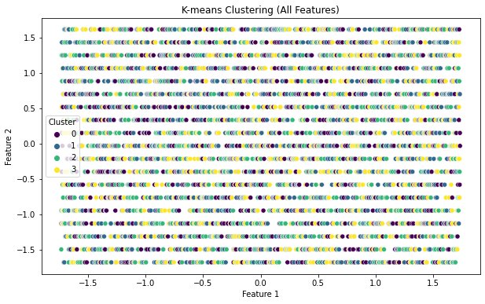

[output not shown]

```python
# Visualized
plt.figure(figsize=(10, 6))
sns.scatterplot(x=UnS_scaled[:, 0], y=UnS_scaled[:, 1], hue=data['ClusterK01'], palette='viridis')
plt.title('K-means Clustering (All Features)')
plt.xlabel('Feature 1')
plt.ylabel('Feature 2')
plt.legend(title='Cluster')
plt.show()

# 查看每群的特徵均值
cluster_means = data.groupby('ClusterK01').mean()
print(cluster_means)
```

**沒有先行篩選特徵的結果如上，非常雜亂，看不出有任何結構可言**

我只是單純好奇全部丟進去它會不會幫我聰明分類而已

**The results without prior feature selection are as follows. They are very messy and there is no structure to speak of.**

I'm just curious if it can help me sort them smartly if I throw them all in.

#### Clustering after Feature Selection

```python
features = ['Field_of_Study', 'Perceived_Effectiveness_of_VR','Engagement_Level',
            'Age', 'Stress_Level_with_VR_Usage']
Xf = encoded_data[features]


# 標準化
standardF = StandardScaler()
Xf_scaled = standardF.fit_transform(Xf)

# 使用 K-means 進行分群
kmF = KMeans(n_clusters=3, init="k-means++", random_state=47)
encoded_data['ClusterF'] = kmF.fit_predict(Xf_scaled)
```

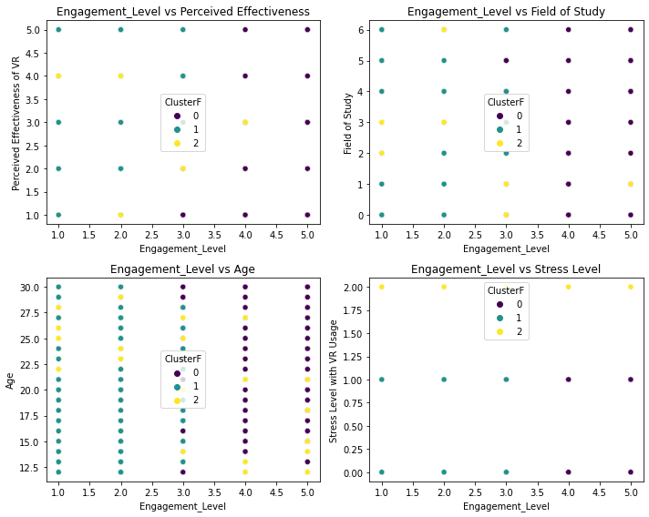

```
          Field_of_Study  Perceived_Effectiveness_of_VR  Engagement_Level  \
ClusterF
0               3.041789                       2.701001          4.224250
1               3.046429                       3.217262          1.803571
2               2.988279                       2.938927          3.022825

                Age  Stress_Level_with_VR_Usage
ClusterF
0         21.501471                    0.480871
1         21.009524                    0.510119
2         21.026527                    2.000000
```

```python
import matplotlib.pyplot as plt
import seaborn as sns

# Create the canvas, and set (2 row, 2 columns)
fig, axes = plt.subplots(2, 2, figsize=(10, 8))

mainF01 = 'Engagement_Level'

# First graph
sns.scatterplot(
    x=Xf[mainF01],
    y=Xf['Perceived_Effectiveness_of_VR'],
    hue=encoded_data['ClusterF'],
    palette='viridis',
    ax=axes[0,0]  # 指定子圖位置 Specify sub-image position
)
axes[0,0].set_title(f'{mainF01} vs Perceived Effectiveness')
axes[0,0].set_xlabel(mainF01)
axes[0,0].set_ylabel('Perceived Effectiveness of VR')

# Second graph
sns.scatterplot(
    x=Xf[mainF01],
    y=Xf['Field_of_Study'],
    hue=encoded_data['ClusterF'],
    palette='viridis',
    ax=axes[0,1]
)
axes[0,1].set_title(f'{mainF01} vs Field of Study')
axes[0,1].set_xlabel(mainF01)
axes[0,1].set_ylabel('Field of Study')

# Third graph
sns.scatterplot(
    x=Xf[mainF01],
    y=Xf['Age'],
    hue=encoded_data['ClusterF'],
    palette='viridis',
    ax=axes[1,0]
)
axes[1,0].set_title(f'{mainF01} vs Age')
axes[1,0].set_xlabel(mainF01)
axes[1,0].set_ylabel('Age')

# Forth graph
sns.scatterplot(
    x=Xf[mainF01],
    y=Xf['Stress_Level_with_VR_Usage'],
    hue=encoded_data['ClusterF'],
    palette='viridis',
    ax=axes[1,1]
)
axes[1,1].set_title(f'{mainF01} vs Stress Level')
axes[1,1].set_xlabel(mainF01)
axes[1,1].set_ylabel('Stress Level with VR Usage')


plt.tight_layout()
plt.show()


# 查看每群的特徵均值 View the features means of each group
cluster_means = encoded_data.groupby('ClusterF')[features].mean()
print(cluster_means)
```

### 1. Engagement Level vs Perceived Effectiveness

This chart shows the breakdown of engagement levels and perceived effectiveness of VR.

- **Observation points**: The data points are mainly distributed between engagement levels (Engagement_Level) 1 to 5, and there is a certain distinction between different clusters (ClusterF=0, 1, 2).
- **Possible conclusion**:
  - Cluster 0 has data points with high engagement and low perceived effect of VR.
  - Cluster 1 may have a high perceived effect but a wide distribution of participation.
  - Cluster 2 has moderate perceived effects and involvement.

### 2. Engagement Level vs Field of Study

This figure explores the clustering relationship between "Participation Level" and "Learning Area".

### **☆3. Engagement Level vs Age**

This chart examines the distribution of "participation level" and "age".

### **☆4. Engagement Level vs Stress Level**

This chart shows the breakdown of engagement levels and stress levels.

### **1. Engagement Level vs Perceived Effectiveness**

這張圖展示了「參與程度」與「對VR有效性的感知」之間的分群情況。

- **觀察點**：資料點主要分布在參與程度（Engagement_Level）1到5之間，並且對於不同群集（ClusterF=0、1、2）有一定的區分。
- **可能結論**：
  - Cluster 0 的資料點集中在高參與程度，且對VR的感知效果較低。
  - Cluster 1 則可能有較高的感知效果但參與程度分布廣泛。
  - Cluster 2 的感知效果和參與程度都偏中等。

### **2. Engagement Level vs Field of Study**

此圖探索了「參與程度」與「學習領域」之間的分群關係。

### **☆3. Engagement Level vs Age**

這張圖檢視了「參與程度」與「年齡」的分布情況。

### **☆4. Engagement Level vs Stress Level**

這張圖展示了「參與程度」與「壓力水準」之間的分群情況。

```python
# Refer to RF & PCA，target is 'Engagement_Level'
f_engaged = ['Stress_Level_with_VR_Usage', 'Age', 'Grade_Level', 'Subject']
Xfe = encoded_data[f_engaged]


# 標準化數據
standardF = StandardScaler()
Xfe_scaled = standardF.fit_transform(Xfe)

# 使用 KMeans 進行分群
kmFe = KMeans(n_clusters=3, init="k-means++", random_state=49)
encoded_data['ClusterFe'] = kmFe.fit_predict(Xfe_scaled)
```

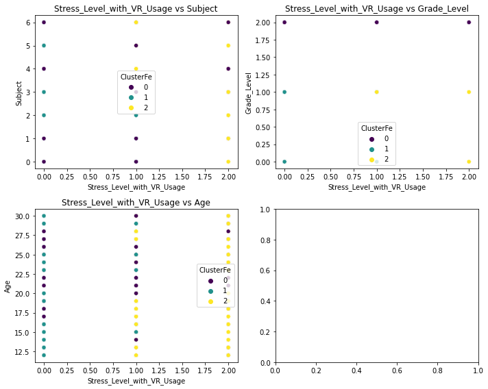

```
           Stress_Level_with_VR_Usage        Age  Grade_Level   Subject
ClusterFe
0                            0.968546  21.137092     2.000000  3.019585
1                            0.318595  21.533010     0.491823  2.387038
2                            1.657452  20.879808     0.503005  3.635817
```

```python
import matplotlib.pyplot as plt
import seaborn as sns

# Create the canvas, and set (2 row, 2 columns)
fig, axes = plt.subplots(2, 2, figsize=(10, 8))

mainF01 = 'Stress_Level_with_VR_Usage'

# First graph
sns.scatterplot(
    x=Xfe[mainF01],
    y=Xfe['Subject'],
    hue=encoded_data['ClusterFe'],
    palette='viridis',
    ax=axes[0,0]
)
axes[0,0].set_title(f'{mainF01} vs Subject')
axes[0,0].set_xlabel(mainF01)
axes[0,0].set_ylabel('Subject')

# Second graph
sns.scatterplot(
    x=Xfe[mainF01],
    y=Xfe['Grade_Level'],
    hue=encoded_data['ClusterFe'],
    palette='viridis',
    ax=axes[0,1]
)
axes[0,1].set_title(f'{mainF01} vs Grade_Level')
axes[0,1].set_xlabel(mainF01)
axes[0,1].set_ylabel('Grade_Level')

# Third graph
sns.scatterplot(
    x=Xfe[mainF01],
    y=Xfe['Age'],
    hue=encoded_data['ClusterFe'],
    palette='viridis',
    ax=axes[1,0]  #
)
axes[1,0].set_title(f'{mainF01} vs Age')
axes[1,0].set_xlabel(mainF01)
axes[1,0].set_ylabel('Age')



plt.tight_layout()
plt.show()


# 查看每群的特徵均值 View the features means of each group
cluster_means_fe = encoded_data.groupby('ClusterFe')[f_engaged].mean()
print(cluster_means_fe)
```

### 1. **Stress Level with VR Usage vs Subject**

This chart shows the breakdown of stress levels and subjects.

**Observation points**:

- Stress level (Stress_Level_with_VR_Usage) ranges from 0 to 2, and different clusters (Cluster 0, 1, 2) show differences in their choice of subjects.
- **Cluster 0** has both high and low pressure.
- **Cluster 1** has lower pressure and is distributed in a few specific disciplines.
- **Cluster 2** has the highest pressure, which is related to the distribution of certain subjects.

**Possible conclusion**:

### 2. **Stress Level with VR Usage vs Grade Level**

This chart shows the breakdown of stress levels and grades.

**Observation points**:

**Possible conclusion**:

### 3. **Stress Level with VR Usage vs Age**

This chart shows the breakdown of stress levels and age groups.

**Observation points**:

**Possible conclusion**:

### 1. **Stress Level with VR Usage vs Subject**

這張圖展示了「壓力水準」與「主修學科」之間的分群情況。

**觀察點**：

- 壓力水準（Stress_Level_with_VR_Usage）分佈於 0 至 2 之間，且不同的群體（Cluster 0, 1, 2）在學科的選擇上呈現差異。
- **Cluster 0** 壓力高低皆有。
- **Cluster 1** 壓力較低，分布於特定少數學科。
- **Cluster 2** 壓力最高，與某些學科的分佈相關。

**可能結論**：

### 2. **Stress Level with VR Usage vs Grade Level**

這張圖展示了「壓力水準」與「年級」之間的分群情況。

**觀察點**：

**可能結論**：

### 3. **Stress Level with VR Usage vs Age**

這張圖展示了「壓力水準」與「年齡」之間的分群情況。

**觀察點**：

**可能結論**：

```python
# 人工篩選(10)，標準 —— 1.不是只有0與1的欄位 2.比較好奇的 3.看起來比較能分群的
features02 = ['Age', 'Gender', 'Grade_Level', 'Field_of_Study', 'Hours_of_VR_Usage_Per_Week',
              'Engagement_Level','Subject', 'Perceived_Effectiveness_of_VR',
              'Stress_Level_with_VR_Usage', 'Impact_on_Creativity',
             'Feedback_from_Educators_on_VR', 'Region']
Xf02 = encoded_data[features02]


# 標準化數據
standardF = StandardScaler()
Xf02_scaled = standardF.fit_transform(Xf02)

# 將標準化數據轉換回 DataFrame
#Xf02_scaled_df = pd.DataFrame(Xf02_scaled, columns=features02)

# 使用 KMeans 進行分群
kmF02 = KMeans(n_clusters=2, init="k-means++", random_state=48)
encoded_data['ClusterF02'] = kmF02.fit_predict(Xf02_scaled)
```

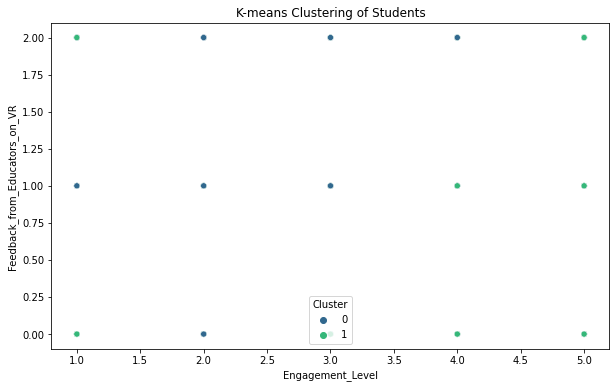

```
                  Age    Gender  Grade_Level  Field_of_Study  \
ClusterF02
0           21.173583  2.493216     1.016361        3.006784
1           21.190858  0.510826     0.991179        3.045309

            Hours_of_VR_Usage_Per_Week  Engagement_Level   Subject  \
ClusterF02
0                             5.092578          3.008779  3.033919
1                             4.957899          3.034082  2.997594

            Perceived_Effectiveness_of_VR  Stress_Level_with_VR_Usage  \
ClusterF02
0                                2.925778                    0.977255
1                                2.977546                    0.989174

            Impact_on_Creativity  Feedback_from_Educators_on_VR    Region
ClusterF02
0                       3.019553                       1.027135  2.508380
1                       3.019647                       1.020048  2.486367
```

```python
# 可視化分群結果
plt.figure(figsize=(10, 6))
sns.scatterplot(x=Xf02['Engagement_Level'], y=Xf02['Feedback_from_Educators_on_VR'],
                hue=encoded_data['ClusterF02'], palette='viridis')
plt.title('K-means Clustering of Students')
plt.xlabel('Engagement_Level')
plt.ylabel('Feedback_from_Educators_on_VR')
plt.legend(title='Cluster')
plt.show()

# 查看每群的特徵均值
cluster_means02 = encoded_data.groupby('ClusterF02')[features02].mean()
print(cluster_means02)
```

上圖可以看出'Engagement_Level'和'Feedback_from_Educators_on_VR'呈現的分群。

The above figure shows the clustering presented by 'Engagement_Level' and 'Feedback_from_Educators_on_VR'.

### Use Elbow Method and Silhouette score to find the best K value (Tools)

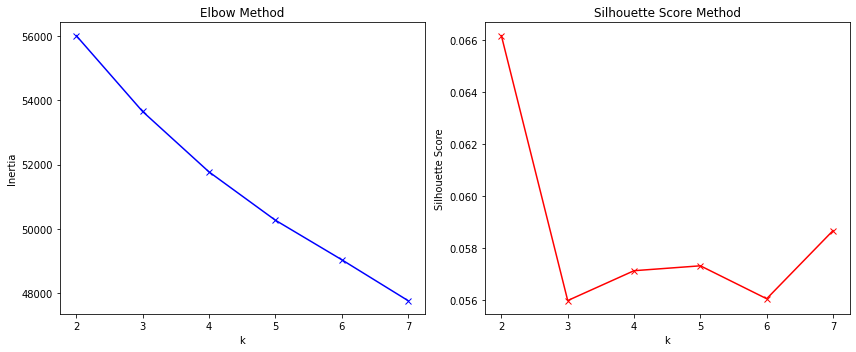

```
Inertia values:
K=2: 56006.98
K=3: 53649.18
K=4: 51773.40
K=5: 50272.22
K=6: 49044.46
K=7: 47772.47

Silhouette scores:
K=2: 0.066
K=3: 0.056
K=4: 0.057
K=5: 0.057
K=6: 0.056
K=7: 0.059
```

```python
from sklearn.metrics import silhouette_score

# 使用肘部法則找最佳K值
inertias = []
silhouette_scores = []
K = range(2, 8)

for k in K:
    kmE = KMeans(n_clusters=k, random_state=77)
    kmE.fit(Xf02_scaled)
    inertias.append(kmE.inertia_)
    silhouette_scores.append(silhouette_score(Xf02_scaled, kmE.labels_))

# 繪製肘部法則圖
plt.figure(figsize=(12, 5))
plt.subplot(1, 2, 1)
plt.plot(K, inertias, 'bx-')
plt.xlabel('k')
plt.ylabel('Inertia')
plt.title('Elbow Method')

# 繪製輪廓分數圖
plt.subplot(1, 2, 2)
plt.plot(K, silhouette_scores, 'rx-')
plt.xlabel('k')
plt.ylabel('Silhouette Score')
plt.title('Silhouette Score Method')
plt.tight_layout()
plt.show()

# 印出具體數值
print("\nInertia values:")
for k, inertia in zip(K, inertias):
    print(f"K={k}: {inertia:.2f}")

print("\nSilhouette scores:")
for k, score in zip(K, silhouette_scores):
    print(f"K={k}: {score:.3f}")
```

### DBSCAN

```python
from sklearn.cluster import DBSCAN
import numpy as np
# 設定 DBSCAN 參數
dbscan = DBSCAN(eps=2.6, min_samples=1)  # 調整 eps 和 min_samples 以獲得最佳效果
clustersDB = dbscan.fit_predict(Xf02_scaled)


encoded_data['ClusterDB'] = clustersDB
print("Cluster labels:", np.unique(clustersDB))
```

```
Cluster labels: [0 1 2]
```

**Find the number of distance, and try to change the eps and min_sample**

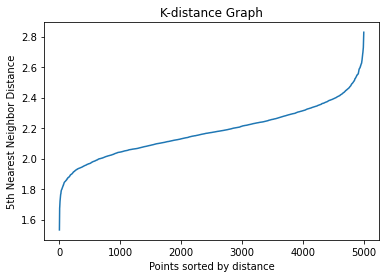

```python
from sklearn.neighbors import NearestNeighbors
import matplotlib.pyplot as plt

# 計算 k-距離
nearest_neighbors = NearestNeighbors(n_neighbors=5)
neighbors = nearest_neighbors.fit(Xf02_scaled)
distances, indices = neighbors.kneighbors(Xf02_scaled)

# 對 k-距離進行排序並繪圖
distances = np.sort(distances[:, -1])  # 取每個點到第 k 個鄰居的距離
plt.plot(distances)
plt.title('K-distance Graph')
plt.xlabel('Points sorted by distance')
plt.ylabel('5th Nearest Neighbor Distance')
plt.show()
```

```python
# 統計每個群集的樣本數 Count the number of samples in each cluster
from collections import Counter

cluster_counts = Counter(clustersDB)
print("Cluster distribution:", cluster_counts)
```

```
Cluster distribution: Counter({0: 4998, 1: 1, 2: 1})
```

**As we can see, the distributions aren't good. Need to try more, like change the features' subsets.**

### 選特徵專區 (Selected Features Area) RandomForest & PCA

**用於回推上面用到的各個不同子集之成分分析，藉此篩選特徵欄位**  
因為有一直不停嘗試，所以就不占版面，就放其中一回的而已

**Used to deduce the component analysis of different subsets used above to filter feature fields**  
Because I have been trying it non-stop, I won’t take up too much space, just post one of them.

- ### RandomForest

[output not shown]

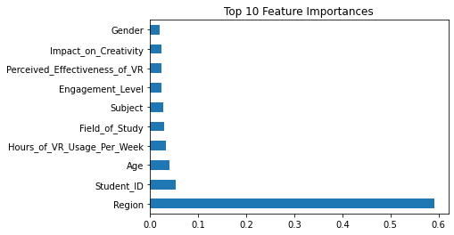

```
Index(['Region', 'Student_ID', 'Age', 'Hours_of_VR_Usage_Per_Week',
       'Field_of_Study'],
      dtype='object')
```

```python
from sklearn.ensemble import RandomForestClassifier
import numpy as np

featuresRF = UnS
targetRF = UnS['Region']

# 訓練隨機森林
rfUnS = RandomForestClassifier(random_state=404)
rfUnS.fit(featuresRF, targetRF)

# 提取特徵重要性
feature_importances = pd.Series(rfUnS.feature_importances_, index=featuresRF.columns)
selected_featuresRF = feature_importances.nlargest(5).index
print("Selected Features:", selected_features)

# 視覺化特徵重要性
feature_importances.nlargest(10).plot(kind='barh')
plt.title('Top 10 Feature Importances')
plt.show()

print(selected_featuresRF)
```

- ### PCA

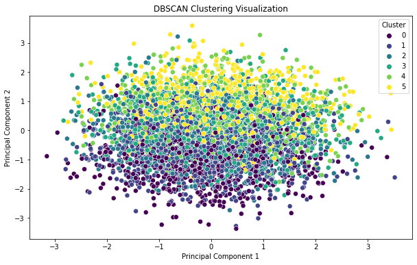

```python
from sklearn.decomposition import PCA
import seaborn as sns

# 使用 PCA 將數據降維到 2D
pca = PCA(n_components=2)
X_pca = pca.fit_transform(UnS_scaled)

# 可視化分群結果
plt.figure(figsize=(10, 6))
sns.scatterplot(x=X_pca[:, 0], y=X_pca[:, 1], hue=encoded_data['Region'], palette='viridis', s=50)
plt.title('DBSCAN Clustering Visualization')
plt.xlabel('Principal Component 1')
plt.ylabel('Principal Component 2')
plt.legend(title='Cluster')
plt.show()
```

```python
# 回推 PCA 主成分影響欄位 Back-calculating PCA principal component influence columns

# 提取特徵負荷量 Extract characteristic load
feature_loadings = pd.DataFrame(
    pca.components_.T,  # 轉置，讓行對應原始特徵 Transpose so that the rows correspond to the original features
    columns=[f'PC{i+1}' for i in range(pca.n_components_)],
    index=UnS.columns  # 原始特徵名稱 Original feature name
)

print(feature_loadings)
```

```
                                               PC1       PC2
Student_ID                                0.373300 -0.016025
Age                                       0.195304  0.020367
Gender                                   -0.199030 -0.178789
Grade_Level                              -0.351304  0.177466
Field_of_Study                            0.043793  0.032755
Usage_of_VR_in_Education                 -0.441012  0.051863
Hours_of_VR_Usage_Per_Week                0.130212 -0.046391
Engagement_Level                          0.205880 -0.166722
Improvement_in_Learning_Outcomes          0.248982  0.106644
Subject                                  -0.045925  0.188375
Instructor_VR_Proficiency                -0.004008  0.267805
Perceived_Effectiveness_of_VR             0.060178  0.342473
Access_to_VR_Equipment                   -0.117011  0.232398
Impact_on_Creativity                     -0.245227  0.192926
Stress_Level_with_VR_Usage                0.136366  0.177513
Collaboration_with_Peers_via_VR          -0.321254 -0.335302
Feedback_from_Educators_on_VR            -0.331006  0.230138
Interest_in_Continuing_VR_Based_Learning -0.041048  0.185314
Region                                    0.098683  0.559894
School_Support_for_VR_in_Curriculum      -0.139175 -0.174182
```

```python
# 找到對 PC1 貢獻最大的特徵
top_features_pc1 = feature_loadings['PC1'].abs().sort_values(ascending=False).head(5)
print("Top Features for PC1:\n", top_features_pc1)

top_features_pc2 = feature_loadings['PC2'].abs().sort_values(ascending=False).head(5)
print("\nTop Features for PC2:\n", top_features_pc2)
```

```
Top Features for PC1:
 Usage_of_VR_in_Education           0.441012
Student_ID                         0.373300
Grade_Level                        0.351304
Feedback_from_Educators_on_VR      0.331006
Collaboration_with_Peers_via_VR    0.321254
Name: PC1, dtype: float64

Top Features for PC2:
 Region                             0.559894
Perceived_Effectiveness_of_VR      0.342473
Collaboration_with_Peers_via_VR    0.335302
Instructor_VR_Proficiency          0.267805
Access_to_VR_Equipment             0.232398
Name: PC2, dtype: float64
```

## References

- https://ithelp.ithome.com.tw/m/articles/10221205
- https://jimmy-huang.medium.com/kmeans%E5%88%86%E7%BE%A4%E6%BC%94%E7%AE%97%E6%B3%95-%E8%88%87-silhouette-%E8%BC%AA%E5%BB%93%E5%88%86%E6%9E%90-8be17e634589
- https://axk51013.medium.com/%E4%B8%8D%E8%A6%81%E5%86%8D%E7%94%A8k-means-%E8%B6%85%E5%AF%A6%E7%94%A8%E5%88%86%E7%BE%A4%E6%B3%95dbscan%E8%A9%B3%E8%A7%A3-a33fa287c0e
- https://axk51013.medium.com/2021%E5%B9%B4%E8%B3%87%E6%96%99%E7%A7%91%E5%AD%B8%E5%AE%B6%E5%BF%85%E5%82%99%E5%88%86%E7%BE%A4%E6%B3%95hdbscan%E7%B0%A1%E4%BB%8B-fba8287e666c